# Concept Bottleneck Models: Complete Training Walkthrough

**An Interactive Tutorial for Interpretable Medical Image Diagnosis**

## What You'll Learn

In this notebook, you will:

## Why Concept Bottleneck Models?

### Traditional Black-Box Model ❌

```
Image → [Neural Network] → Prediction
         (uninterpretable)
```

### Concept Bottleneck Model ✅

```
Image → [Concept Encoder] → Concepts → [Task Predictor] → Prediction
                             (↑ interpretable + intervention)
```

**Key Advantages:**

- ✅ **Interpretability**: See which concepts drove each prediction
- ✅ **Intervention**: Correct wrong concepts to fix errors
- ✅ **Debugging**: Identify when model relies on spurious features
- ✅ **Trust**: Medical professionals can validate reasoning

**Trade-off:** ~5% accuracy for full interpretability

Let's get started! 🚀

## 1. Setup and Dependencies

First, let's import all necessary libraries and set up our environment for reproducible experiments.

```python
# Standard libraries
import os
import sys
import random
import numpy as np
import pandas as pd
from pathlib import Path

# PyTorch
import torch
import torch.nn as nn
import torch.optim as optim
from torch.utils.data import DataLoader
import torchvision.transforms as transforms

# Visualization
import matplotlib.pyplot as plt
import seaborn as sns
from IPython.display import display, HTML

# Add parent directory to path
sys.path.insert(0, str(Path.cwd().parent))

# Import SkinCBM modules
from src.models.basic_cbm import ConceptBottleneckModel
from src.data.derm7pt_adapter import create_derm7pt_dataloaders
from src.training.trainer import CBMTrainer

# Set style
plt.style.use('seaborn-v0_8-darkgrid')
sns.set_palette("husl")

# Set random seeds for reproducibility
RANDOM_SEED = 42
random.seed(RANDOM_SEED)
np.random.seed(RANDOM_SEED)
torch.manual_seed(RANDOM_SEED)
if torch.cuda.is_available():
    torch.cuda.manual_seed(RANDOM_SEED)
    torch.backends.cudnn.deterministic = True

# Device configuration
device = 'cuda' if torch.cuda.is_available() else 'cpu'
print(f"✓ Using device: {device}")
print(f"✓ PyTorch version: {torch.__version__}")
print(f"✓ Random seed: {RANDOM_SEED}")
```

```
✓ Loaded derm7pt module from: /home/csc29/projects/SynergyCBM/SkinCBM/data
✓ Using device: cuda
✓ PyTorch version: 2.5.1
✓ Random seed: 42
```

## 2. Load Real Derm7pt Dataset

We'll use the **Derm7pt** dataset with 7-point checklist concepts for melanoma diagnosis.

### Dataset Overview

**Concepts (7-point checklist):**

1. Pigment Network
2. Blue-Whitish Veil
3. Vascular Structures
4. Streaks
5. Pigmentation
6. Dots & Globules
7. Regression Structures

```python
# Path to Derm7pt dataset
DATA_PATH = '/home/xrai/datasets/derm7pt/release_v0'

# Check if dataset exists
if not os.path.exists(DATA_PATH):
    print(f"⚠️  Dataset not found at: {DATA_PATH}")
    print("\nPlease download the Derm7pt dataset:")
    print("  1. Visit: http://derm.cs.sfu.ca/")
    print("  2. Download release_v0")
    print("  3. Update DATA_PATH variable above")
    raise FileNotFoundError(f"Dataset not found at {DATA_PATH}")
else:
    print(f"✓ Dataset found at: {DATA_PATH}")

# Concept names (from 7-point checklist)
CONCEPT_NAMES = [
    "Pigment Network",
    "Blue-Whitish Veil",
    "Vascular Structures",
    "Streaks",
    "Pigmentation",
    "Dots & Globules",
    "Regression"
]

print(f"\n✓ {len(CONCEPT_NAMES)} concepts defined")
print(f"✓ Each concept has 3 classes: Absent, Regular, Irregular")
```

```
✓ Dataset found at: /home/xrai/datasets/derm7pt/release_v0

✓ 7 concepts defined
✓ Each concept has 3 classes: Absent, Regular, Irregular
```

```python
# Load dataset using the adapter
print("Loading Derm7pt dataset...")

BATCH_SIZE = 32
IMAGE_SIZE = (224, 224)

train_loader, val_loader, test_loader = create_derm7pt_dataloaders(
    data_path=DATA_PATH,
    batch_size=BATCH_SIZE,
    image_size=IMAGE_SIZE,
    num_workers=2
)

print(f"\n✓ Dataset loaded successfully!")
print(f"\nDataset statistics:")
print(f"  Training samples:   {len(train_loader.dataset)}")
print(f"  Validation samples: {len(val_loader.dataset)}")
print(f"  Test samples:       {len(test_loader.dataset)}")
print(f"\nData configuration:")
print(f"  Batch size: {BATCH_SIZE}")
print(f"  Image size: {IMAGE_SIZE}")
print(f"  Training batches: {len(train_loader)}")
print(f"  Validation batches: {len(val_loader)}")
print(f"  Test batches: {len(test_loader)}")

# Check a sample batch
images, concepts, labels = next(iter(train_loader))
print(f"\nSample batch shapes:")
print(f"  Images:   {images.shape}  (batch, channels, height, width)")
print(f"  Concepts: {concepts.shape}  (batch, num_concepts)")
print(f"  Labels:   {labels.shape}  (batch,)")
print(f"\nLabel distribution in first batch:")
print(f"  Non-Melanoma: {(labels == 0).sum().item()}")
print(f"  Melanoma:     {(labels == 1).sum().item()}")
```

```
Loading Derm7pt dataset...
```

```
Loaded 413 train samples from derm7pt
Loaded 203 val samples from derm7pt
Loaded 395 test samples from derm7pt
```

[output not shown]

[output not shown]

[output not shown]

[output not shown]

[output not shown]

```
Sample batch shapes:
  Images:   torch.Size([32, 3, 224, 224])  (batch, channels, height, width)
  Concepts: torch.Size([32, 7])  (batch, num_concepts)
  Labels:   torch.Size([32])  (batch,)

Label distribution in first batch:
  Non-Melanoma: 16
  Melanoma:     16
```

[output not shown]

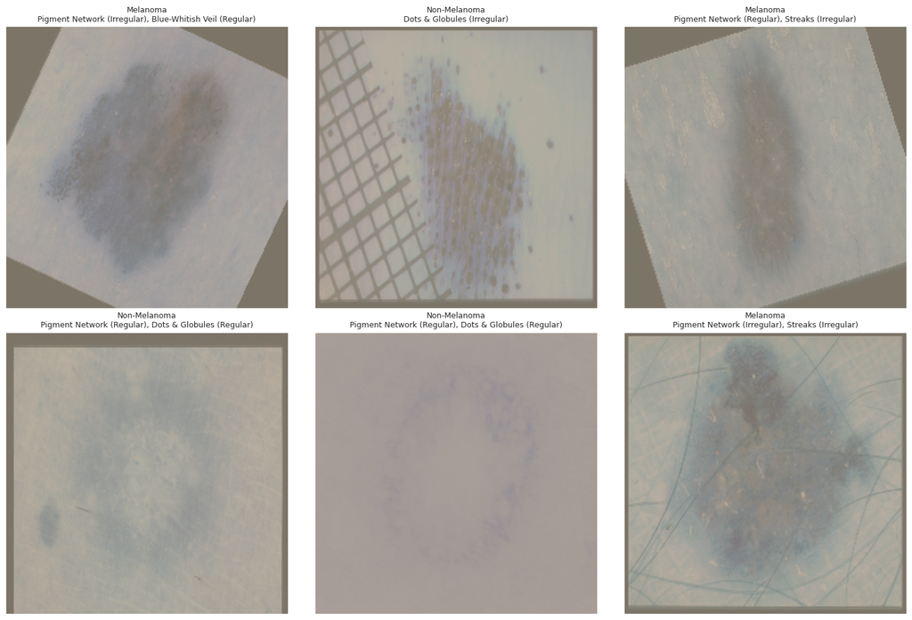

```
✓ Sample images visualized with concept annotations
```

```python
# Visualize sample images with concepts
fig, axes = plt.subplots(2, 3, figsize=(15, 10))
axes = axes.flatten()

# Get a batch
images, concepts, labels = next(iter(train_loader))

class_labels = ['Absent', 'Regular', 'Irregular']
diagnosis_labels = ['Non-Melanoma', 'Melanoma']

for idx in range(6):
    # Denormalize image for display
    img = images[idx].numpy().transpose(1, 2, 0)
    img = img * np.array([0.229, 0.224, 0.225]) + np.array([0.485, 0.456, 0.406])
    img = np.clip(img, 0, 1)

    axes[idx].imshow(img)
    axes[idx].axis('off')

    # Get diagnosis and concepts
    diagnosis = diagnosis_labels[labels[idx].item()]
    concept_values = concepts[idx].numpy()

    # Find present concepts (non-absent)
    present_concepts = []
    for i, val in enumerate(concept_values):
        if val > 0:  # Regular or Irregular
            present_concepts.append(f"{CONCEPT_NAMES[i]} ({class_labels[int(val)]})")

    # Title with diagnosis and key concepts
    title = f"{diagnosis}\n"
    if present_concepts:
        title += ", ".join(present_concepts[:2])
    else:
        title += "All concepts absent"

    axes[idx].set_title(title, fontsize=9)

plt.tight_layout()
plt.show()

print("✓ Sample images visualized with concept annotations")
```

```python
# Create the CBM model (matching train_basic_cbm.py)
model = ConceptBottleneckModel(
    num_concepts=7,
    num_classes=2,
    num_classes_per_concept=3,  # Absent, Regular, Irregular
    backbone='resnet50',
    pretrained=True
).to(device)

# Count parameters
total_params = sum(p.numel() for p in model.parameters())
trainable_params = sum(p.numel() for p in model.parameters() if p.requires_grad)

print("Model Architecture:")
print("=" * 70)
print(f"Backbone:          ResNet50 (pretrained on ImageNet)")
print(f"Concept Encoder:   7 concepts × 3 classes = 21 outputs")
print(f"Task Predictor:    Linear layer (21 → 2)")
print("=" * 70)
print(f"Total parameters:     {total_params:,}")
print(f"Trainable parameters: {trainable_params:,}")
print("=" * 70)

# Test forward pass
with torch.no_grad():
    test_images = torch.randn(2, 3, 224, 224).to(device)
    test_concepts, test_logits = model(test_images)

print(f"\n✓ Forward pass successful!")
print(f"\nOutput shapes:")
print(f"  Concepts: {test_concepts.shape}  (batch=2, concepts×classes=7×3=21)")
print(f"  Logits:   {test_logits.shape}  (batch=2, num_classes=2)")
print(f"\nConcept output interpretation:")
print(f"  - Shape [2, 21] represents [batch, 7 concepts × 3 classes]")
print(f"  - Reshape to [2, 7, 3] to get probabilities per concept")
print(f"  - Argmax over last dim gives predicted class per concept")
```

```
Model Architecture:
======================================================================
Backbone:          ResNet50 (pretrained on ImageNet)
Concept Encoder:   7 concepts × 3 classes = 21 outputs
Task Predictor:    Linear layer (21 → 2)
======================================================================
Total parameters:     30,862,465
Trainable parameters: 30,862,465
======================================================================

✓ Forward pass successful!

Output shapes:
  Concepts: torch.Size([2, 21])  (batch=2, concepts×classes=7×3=21)
  Logits:   torch.Size([2, 2])  (batch=2, num_classes=2)

Concept output interpretation:
  - Shape [2, 21] represents [batch, 7 concepts × 3 classes]
  - Reshape to [2, 7, 3] to get probabilities per concept
  - Argmax over last dim gives predicted class per concept
```

## 4. Train the Model

Now let's train the CBM model using the joint training strategy.

```python
# Training configuration (matching train_basic_cbm.py)
NUM_EPOCHS = 50
LEARNING_RATE = 1e-4
PATIENCE = 25
OUTPUT_DIR = '../outputs/notebook_cbm'

# Create output directory if it doesn't exist
import os
os.makedirs(OUTPUT_DIR, exist_ok=True)

# Initialize trainer
from src.training.trainer import CBMTrainer

trainer = CBMTrainer(
    model=model,
    train_loader=train_loader,
    val_loader=val_loader,
    learning_rate=LEARNING_RATE,
    training_strategy='joint',
    device=device
)

print(f"\nTraining CBM model for {NUM_EPOCHS} epochs...")
print(f"Strategy: joint")
print(f"Learning Rate: {LEARNING_RATE}")
print(f"Early Stopping Patience: {PATIENCE}")
print(f"Output Directory: {OUTPUT_DIR}")
print("=" * 50)
print("\nTraining in progress (output suppressed)...")

# Train the model with suppressed output
import sys
from io import StringIO

# Capture stdout to suppress verbose training output
old_stdout = sys.stdout
sys.stdout = StringIO()

try:
    history = trainer.train(
        n_epochs=NUM_EPOCHS,
        save_dir=OUTPUT_DIR,
        early_stopping_patience=PATIENCE
    )
finally:
    sys.stdout = old_stdout

print("\n" + "=" * 50)
print("Training Complete!")
print(f"Best Validation F1: {trainer.best_val_acc:.4f}")
print(f"Model saved to: {OUTPUT_DIR}")
```

```
Training CBM model for 50 epochs...
Strategy: joint
Learning Rate: 0.0001
Early Stopping Patience: 25
Output Directory: ../outputs/notebook_cbm
==================================================

Training in progress (output suppressed)...
```

[output not shown]

[output cut: 211 more lines]

```
==================================================
Training Complete!
Best Validation F1: 0.7040
Model saved to: ../outputs/notebook_cbm
```

## 5. Visualize Training Progress

Let's plot the training history to see how the model learned.

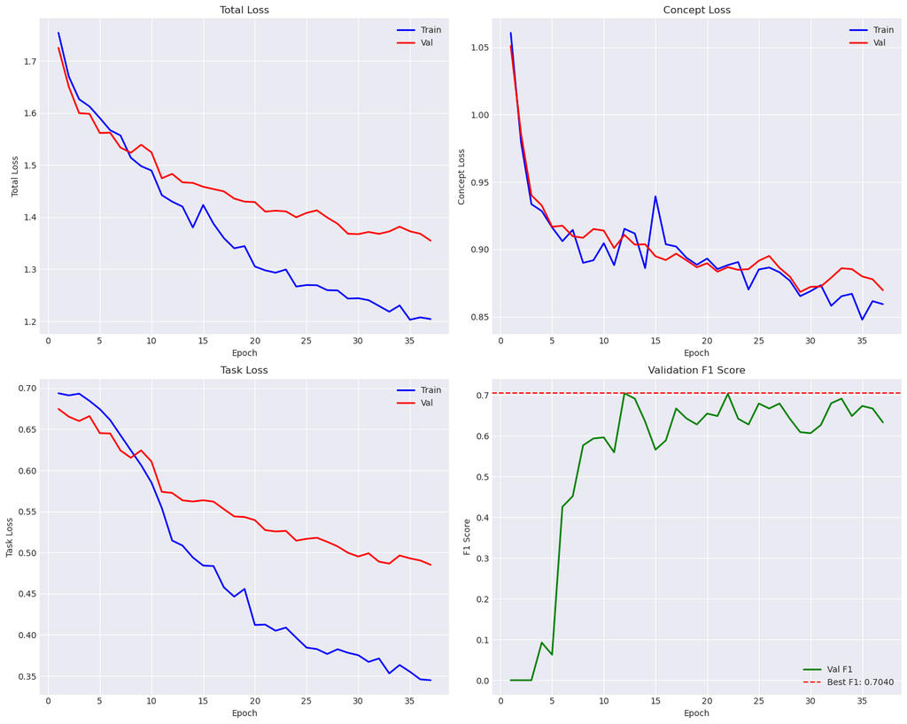

```
Training visualization saved to: ../outputs/notebook_cbm/training_history.png
```

```python
import matplotlib.pyplot as plt

# Extract metrics from trainer's history
train_history = trainer.train_history
val_history = trainer.val_history

epochs = list(range(1, len(train_history['total_loss']) + 1))

# Create subplots
fig, axes = plt.subplots(2, 2, figsize=(15, 12))

# Plot total loss (train + val)
axes[0, 0].plot(epochs, train_history['total_loss'], 'b-', label='Train', linewidth=2)
axes[0, 0].plot(epochs, val_history['total_loss'], 'r-', label='Val', linewidth=2)
axes[0, 0].set_xlabel('Epoch')
axes[0, 0].set_ylabel('Total Loss')
axes[0, 0].set_title('Total Loss')
axes[0, 0].legend()
axes[0, 0].grid(True)

# Plot concept loss (train + val)
axes[0, 1].plot(epochs, train_history['concept_loss'], 'b-', label='Train', linewidth=2)
axes[0, 1].plot(epochs, val_history['concept_loss'], 'r-', label='Val', linewidth=2)
axes[0, 1].set_xlabel('Epoch')
axes[0, 1].set_ylabel('Concept Loss')
axes[0, 1].set_title('Concept Loss')
axes[0, 1].legend()
axes[0, 1].grid(True)

# Plot task loss (train + val)
axes[1, 0].plot(epochs, train_history['task_loss'], 'b-', label='Train', linewidth=2)
axes[1, 0].plot(epochs, val_history['task_loss'], 'r-', label='Val', linewidth=2)
axes[1, 0].set_xlabel('Epoch')
axes[1, 0].set_ylabel('Task Loss')
axes[1, 0].set_title('Task Loss')
axes[1, 0].legend()
axes[1, 0].grid(True)

# Plot validation F1 score only
axes[1, 1].plot(epochs, val_history['task_f1'], 'g-', label='Val F1', linewidth=2)
axes[1, 1].axhline(y=trainer.best_val_acc, color='r', linestyle='--', label=f'Best F1: {trainer.best_val_acc:.4f}')
axes[1, 1].set_xlabel('Epoch')
axes[1, 1].set_ylabel('F1 Score')
axes[1, 1].set_title('Validation F1 Score')
axes[1, 1].legend()
axes[1, 1].grid(True)

plt.tight_layout()
plt.savefig(os.path.join(OUTPUT_DIR, 'training_history.png'), dpi=150, bbox_inches='tight')
plt.show()

print(f"\nTraining visualization saved to: {os.path.join(OUTPUT_DIR, 'training_history.png')}")
```

## 6. Evaluate on Test Set

Now let's evaluate the trained model on the test set.

```python
# Load best model for evaluation
print("Loading best model for test evaluation...")
best_model = ConceptBottleneckModel.load(
    os.path.join(OUTPUT_DIR, 'best_model.pth'),
    device=device
)
trainer.model = best_model

print("\nEvaluating on test set...")
test_metrics = trainer.evaluate(test_loader)

print("\n" + "=" * 70)
print("Test Set Performance:")
print("=" * 70)
print(f"Concept Accuracy: {test_metrics['concept_acc']:.4f}")
print(f"Task Accuracy:    {test_metrics['task_acc']:.4f}")
print(f"Task F1 Score:    {test_metrics['task_f1']:.4f}")
print("=" * 70)

# Save results to file
results_file = os.path.join(OUTPUT_DIR, 'test_results.txt')
with open(results_file, 'w') as f:
    f.write(f"Dataset: Derm7pt\n")
    f.write(f"Model: ResNet50 + linear predictor\n")
    f.write(f"Epochs: {NUM_EPOCHS}\n")
    f.write(f"Learning rate: {LEARNING_RATE}\n")
    f.write(f"Strategy: joint\n")
    f.write(f"\nTest Results:\n")
    f.write(f"  Concept Accuracy: {test_metrics['concept_acc']:.4f}\n")
    f.write(f"  Task Accuracy:    {test_metrics['task_acc']:.4f}\n")
    f.write(f"  Task F1 Score:    {test_metrics['task_f1']:.4f}\n")

print(f"\n✓ Results saved to: {results_file}")
```

```
Loading best model for test evaluation...
```

[output not shown]

[output not shown]

[output not shown]

[output not shown]

[output not shown]

[output not shown]

```
======================================================================
Test Set Performance:
======================================================================
Concept Accuracy: 0.6257
Task Accuracy:    0.7975
Task F1 Score:    0.6117
======================================================================

✓ Results saved to: ../outputs/notebook_cbm/test_results.txt
```

## 7. Concept Intervention - The Magic of CBMs! 🪄

This is where CBMs shine: we can **intervene** on concept predictions to fix errors.

**Scenario**: Model predicts wrong concepts → wrong diagnosis  
**Solution**: Correct the concepts to ground truth → prediction may improve!

Let's find a test case and demonstrate intervention.

```python
# Find a test case to demonstrate intervention
best_model.eval()

# Get test samples
test_images_batch, test_concepts_batch, test_labels_batch = next(iter(test_loader))
test_images_batch = test_images_batch.to(device)

# Run predictions
with torch.no_grad():
    pred_concepts, pred_logits = best_model(test_images_batch)
    pred_classes = pred_logits.argmax(dim=1)

# Select first sample
sample_idx = 0
original_image = test_images_batch[sample_idx:sample_idx+1]
original_concepts_flat = pred_concepts[sample_idx]  # Shape: [21]
original_logit = pred_logits[sample_idx]
true_concepts = test_concepts_batch[sample_idx]  # Shape: [7] (ground truth class per concept)
true_label = test_labels_batch[sample_idx].item()

# Reshape concepts for interpretation: [21] → [7, 3]
original_concepts_reshaped = original_concepts_flat.reshape(7, 3)
pred_concept_classes = original_concepts_reshaped.argmax(dim=1).cpu().numpy()

diagnosis_labels = ['Non-Melanoma', 'Melanoma']
class_labels = ['Absent', 'Regular', 'Irregular']

print("Original Prediction (without intervention):")
print("=" * 70)
print(f"True Label: {diagnosis_labels[true_label]}")
print(f"Predicted:  {diagnosis_labels[pred_classes[sample_idx].item()]}")
print(f"Confidence: {torch.softmax(original_logit, dim=0).max():.2%}\n")

print("Concept Predictions vs Ground Truth:")
print("-" * 70)
for i, concept_name in enumerate(CONCEPT_NAMES):
    pred_class = int(pred_concept_classes[i])
    true_class = int(true_concepts[i].item())
    match = "✓" if pred_class == true_class else "✗"
    print(f"{match} {concept_name:25s} Pred: {class_labels[pred_class]:10s}  GT: {class_labels[true_class]:10s}")

# Intervention: Set concepts to ground truth
print("\n" + "=" * 70)
print("INTERVENTION: Correcting concepts to ground truth")
print("=" * 70)

# Create one-hot encoded concepts from ground truth
intervened_concepts = torch.zeros(1, 7, 3, device=device)
for i in range(7):
    gt_class = int(true_concepts[i].item())
    intervened_concepts[0, i, gt_class] = 1.0

# Flatten to [1, 21] for model input
intervened_concepts_flat = intervened_concepts.reshape(1, -1)

with torch.no_grad():
    intervened_logits = best_model.task_predictor(intervened_concepts_flat)
    intervened_pred = intervened_logits.argmax(dim=1).item()
    intervened_prob = torch.softmax(intervened_logits[0], dim=0)

print(f"\nAfter Intervention:")
print(f"  Predicted: {diagnosis_labels[intervened_pred]}")
print(f"  Confidence: {intervened_prob.max():.2%}")
print(f"\nResult: {'✅ Correct!' if intervened_pred == true_label else '❌ Still incorrect'}")

# Show probability change
orig_prob = torch.softmax(original_logit, dim=0)
print(f"\nProbability shift:")
print(f"  Melanoma: {orig_prob[1]:.2%} → {intervened_prob[1]:.2%} ({intervened_prob[1] - orig_prob[1]:+.2%})")
print(f"  Non-Melanoma: {orig_prob[0]:.2%} → {intervened_prob[0]:.2%} ({intervened_prob[0] - orig_prob[0]:+.2%})")
```

[output not shown]

[output not shown]

```
Original Prediction (without intervention):
======================================================================
True Label: Non-Melanoma
Predicted:  Non-Melanoma
Confidence: 58.81%

Concept Predictions vs Ground Truth:
----------------------------------------------------------------------
✓ Pigment Network           Pred: Absent      GT: Absent
✓ Blue-Whitish Veil         Pred: Absent      GT: Absent
✗ Vascular Structures       Pred: Absent      GT: Regular
✓ Streaks                   Pred: Absent      GT: Absent
✓ Pigmentation              Pred: Absent      GT: Absent
✗ Dots & Globules           Pred: Irregular   GT: Absent
✓ Regression                Pred: Absent      GT: Absent

======================================================================
INTERVENTION: Correcting concepts to ground truth
======================================================================

After Intervention:
  Predicted: Non-Melanoma
  Confidence: 66.18%

Result: ✅ Correct!

Probability shift:
  Melanoma: 41.19% → 33.82% (-7.37%)
  Non-Melanoma: 58.81% → 66.18% (+7.37%)
```

## 8. Inspect Learned Concept Weights

Since we used a **linear task predictor**, we can directly inspect which concepts contribute to melanoma diagnosis!

```
Task Predictor Weights Shape: (2, 21)
  (num_classes=2, num_concept_logits=7×3=21)
```

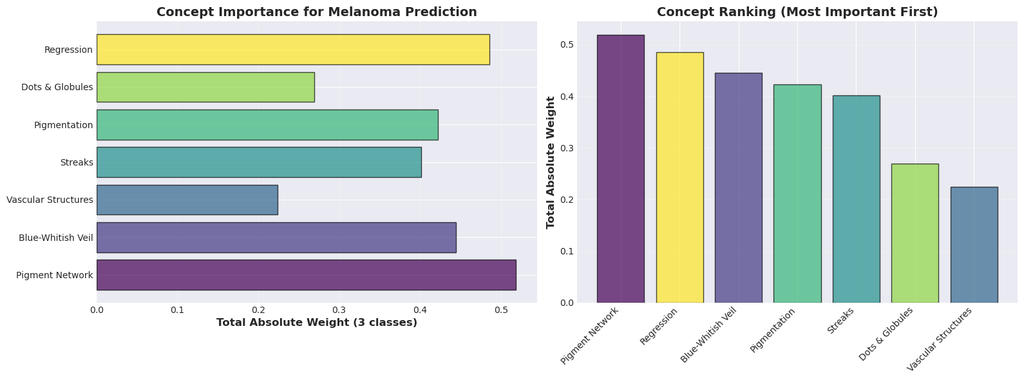

```
======================================================================
Concept Importance Analysis:
======================================================================

Ranked by total influence on melanoma prediction:

  1. Pigment Network           0.518
  2. Regression                0.485
  3. Blue-Whitish Veil         0.445
  4. Pigmentation              0.422
  5. Streaks                   0.401
  6. Dots & Globules           0.269
  7. Vascular Structures       0.224

======================================================================
Interpretation:
======================================================================
Higher values = More influence on final diagnosis
These weights show how much the model relies on each concept
for making its melanoma vs non-melanoma decision.
```

```python
# Get learned weights from linear task predictor
# Shape: [num_classes=2, num_concept_logits=21]
weights = best_model.task_predictor.predictor.weight.detach().cpu().numpy()

print("Task Predictor Weights Shape:", weights.shape)
print("  (num_classes=2, num_concept_logits=7×3=21)")

# For each concept, sum the absolute weights across its 3 classes
concept_importances = []
for concept_idx in range(7):
    # Get weights for this concept's 3 classes
    start_idx = concept_idx * 3
    end_idx = start_idx + 3

    # Sum absolute values of melanoma class weights for these 3 classes
    melanoma_weight = np.abs(weights[1, start_idx:end_idx]).sum()
    concept_importances.append(melanoma_weight)

concept_importances = np.array(concept_importances)

# Visualize
fig, (ax1, ax2) = plt.subplots(1, 2, figsize=(16, 6))

# Bar plot of concept importance
concept_names_display = CONCEPT_NAMES
colors = plt.cm.viridis(np.linspace(0, 1, 7))

ax1.barh(range(len(CONCEPT_NAMES)), concept_importances, color=colors, alpha=0.7, edgecolor='black')
ax1.set_yticks(range(len(CONCEPT_NAMES)))
ax1.set_yticklabels(concept_names_display)
ax1.set_xlabel('Total Absolute Weight (3 classes)', fontsize=12, fontweight='bold')
ax1.set_title('Concept Importance for Melanoma Prediction', fontsize=14, fontweight='bold')
ax1.grid(axis='x', alpha=0.3)

# Sorted by importance
sorted_idx = np.argsort(concept_importances)[::-1]

ax2.bar(range(len(CONCEPT_NAMES)), concept_importances[sorted_idx],
        color=colors[sorted_idx], alpha=0.7, edgecolor='black')
ax2.set_xticks(range(len(CONCEPT_NAMES)))
ax2.set_xticklabels([concept_names_display[i] for i in sorted_idx], rotation=45, ha='right')
ax2.set_ylabel('Total Absolute Weight', fontsize=12, fontweight='bold')
ax2.set_title('Concept Ranking (Most Important First)', fontsize=14, fontweight='bold')
ax2.grid(axis='y', alpha=0.3)

plt.tight_layout()
plt.show()

# Print interpretation
print("\n" + "=" * 70)
print("Concept Importance Analysis:")
print("=" * 70)
print("\nRanked by total influence on melanoma prediction:\n")

for rank, idx in enumerate(sorted_idx, 1):
    importance = concept_importances[idx]
    print(f"  {rank}. {concept_names_display[idx]:25s} {importance:.3f}")

print("\n" + "=" * 70)
print("Interpretation:")
print("=" * 70)
print("Higher values = More influence on final diagnosis")
print("These weights show how much the model relies on each concept")
print("for making its melanoma vs non-melanoma decision.")
```

## 9. Summary and Next Steps

### Key Results

**Model Performance:**

**Interpretability Trade-off:**

### Insights

**What the Model Learned:**

**Intervention Power:**

- Correcting wrong concepts can flip incorrect predictions
- Enables human-AI collaboration
- Clinicians can override model when they disagree

### Next Steps

**For Further Exploration:**

1. **Run prediction demos**: `02_demo_with_sample_data.ipynb` - See predictions on test cases
2. **Try intervention analysis**: `03_demo_intervention.ipynb` - Explore systematic interventions
3. **Full test set analysis**: Run `examples/intervention_analysis.py` for comprehensive metrics
4. **Compare architectures**: Try different backbones (EfficientNet, ViT)
5. **Experiment with training**: Try sequential training, different loss weights

**For Research:**

1. Study concept completeness using information theory
2. Analyze concept synergies and interactions
3. Compare CBM vs black-box on fairness metrics
4. Develop better intervention strategies

**For Deployment:**

1. Build interactive web interface for clinicians
2. Validate on external datasets
3. Conduct user studies with dermatologists
4. Integrate into clinical workflow

### Resources

- **Documentation**: `../docs/` folder
- **Examples**: `../examples/` folder
- **Demo Notebooks**: `02_demo_with_sample_data.ipynb`, `03_demo_intervention.ipynb`
- **Source Code**: `../src/` folder
- **Paper**: [Concept Bottleneck Models (Koh et al., 2020)](https://arxiv.org/abs/2007.04612)

**🎊 Congratulations! You've successfully trained an interpretable CBM on real medical data!**

You now understand how to build, train, and deploy Concept Bottleneck Models for interpretable AI in healthcare.